# Домашняя работа №4: случайные леса (деревьев принятия решений)

kzaitsev

May 1, 2017

# Восстановление возраста по данным метелирования

Данные для этой данной домашней работы мы возьмем из статьи “A novel strategy for forensic age prediction by DNA methylation and support vector regression model”, Cheng Xu et al, Scientific reports 2015. (Статья будет в архиве), где авторы попытались построить предсказатель возраста человека по данным метилирования отдельных CpG sites. Данные будут выглядеть следующим образом:

```r
ages <- read.table("ages.tsv", sep="\t", header=1)
head(ages)
```

```
##   Sample Age              Array
## 1    F78  20 Sequenom Massarray
## 2    F79  21 Sequenom Massarray
## 3    F80  22 Sequenom Massarray
## 4    F81  23 Sequenom Massarray
## 5    F82  24 Sequenom Massarray
## 6    F83  25 Sequenom Massarray
```

В табличке “ages.tsv” лежат идентификаторы доноров, возраст, и название array, которым это всё добро сделали.

```r
methylation <- read.table("methylation.tsv", sep="\t", header=1, row.names = 1, na.strings = "NA")
print(methylation[1:5, 1:5])
```

```
##    Primer Chr                   Position  F78  F79
## X1     P1   1                   43425337 0.24 0.09
## X2     P1   1 43425369;43425373;43425375 0.63 0.25
## X3     P1   1                   43425385 0.69 0.44
## X4     P1   1          43425452;43425460 0.88 0.45
## X5     P1   1                   43425479 0.89 0.43
```

В табличке “methylation.tsv” лежат данные про CpG сайты, где эти сайты на геноме находятся, а что самое главное, доля метилирования каждого сайта у наших доноров. Однако в этой табличке также есть NA-значения, авторы статьи утверждают, что это означает “no methylation detected”, и считают их за 0 (вам я их тоже предлагаю считать за 0).

# Предподготовка данных

Вообще сайтов метилирования там какое-то не очень большое количество (95 сайтов), однако часть из них абсолютно не скоррелирована с возрастом, и наверняка вряд ли поможет нам в решении задачи регрессии. Хочется проделать примерно то же, что проделали авторы статьи – сделать ручками очень простой feature selection. Давайте оставим только те, сайты метилирования, которые наиболее скоррелированы с возрастом.

Переподготовка:

- Для каждого сайта метилирования, посчитать корреляцию между долей метилирования этого сайта в доноре и возрасте донора.
- Оставить только 10 самых скоррелированных сайтов. Под самыми скоррелированными мы понимаем **абсолютное** значение корреляции.

## Предподготовка данных (machine learning)

Ну мы же теперь талантливые computer/data scientists, и знаем, что нужно разделить наши данные на обучающую и тестовую выборку. Я предлагаю сделать это в отношении 80% : 20%, т.е. 40 тренировочных доноров и 10 тестирующих доноров.

Предподготовка:

- Установить random seed тем значением, которое вам нравится
- Сделать разбиение всех доноров на тренировочную и тестирующие выборки

# Построение лесов

Прежде всего стоит напомнить, что мы можем использовать случайные леса также и для задачи регрессии. Если в **decision tree для классификации** мы останавливались в построении дерева, когда в листовой вершине оказывались все объекты одного класса, то в **задаче регрессии** мы хотим, чтобы в листовой вершине были объекты с “относительно близкими” значениями зависимой переменной, которую мы пытаемся предсказать. Тогда среднее значение зависимой переменной по всем объектам внутри листовой вершины и будет предсказывать значение зависимой переменной для новых объектов.

Например, если бы мы хотели, для iris dataset предсказать зависимость Petal.Width ~ Petal.Length + Sepal.Length + Sepal.Width, мы могли бы использовать analysis of variance (ANOVA) метод, для того, чтобы придумывать правила разбиения нашей тренировочной выборки. Затем мы для листовых вершин посчитали бы среднее значение Petal.Width, и регрессия для нового объекта происходила бы следующим образом: двигаться по правилам в дереве, пока не пришёл в листовую вершину; когда пришёл в листовую вершину – верни среднее значение в этой вершине.

На картинке представлено дерево регрессии, со средним значением Petal.Width в каждой вершине.

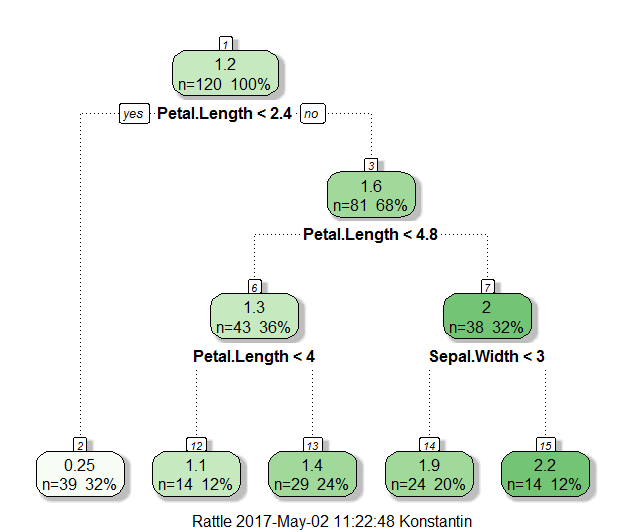

## Функция-обертка

Первая часть задачи будет заключаться в том, чтобы написать функцию-обертку, которая для обучающей и тестирующей выборок, несколько раз построила случайный лес с определенными параметрами, и взяла среднюю ошибку между всеми запусками ошибку на обучающей выборке и на тренирующей выборке.

Что должна делать функция:

- Принимать обучающую и тестирующую выборки, и количество запусков N
- N раз построить randomForest с этими данными
- Для каждого randomForest почитать **RMSE** (root mean squared error) для обучающей и тренирующей выборок
- Посчитать средний **RMSE** для обоих выборок по всем запускам
- Вернуть вектор двух чисел: первое число – средний RMSE на обучающей выборке, второе – средний RMSE на тестирующей выборке.

**RMSE** – root mean square error, пускай $y_i$ – реальное значение возраста, а $\hat{y_i}$ – предсказанное значение возраста, тогда:
$$RMSE = \sqrt{MSE(\hat{y})} = \sqrt{\frac{1}{n} SSE(\hat{y})} = \sqrt{\frac{1}{n} \sum_{i=i}^{n}{(\hat{y_i} - y_i)^2}}$$

Шаблон функции примерно такой:

```r
#' randomForest wrapper and error estimator
#'
#' @param train.data data.frame, training dataset
#' @param train.response numeric vector, values of dependent variables in training dataset
#' @param test.data data.frame, testing (validation) dataset
#' @param test.response numeric vector, values of dependent variables in testing dataset
#' @param runs.number numeric (integer), how many times we should run random forest
#' @param ... parameters that are passes to randomForest function, like
#'        ntree, mtry, nodesize, replace, sampsize
#'
#' @return numeric vector with two values,
#'      first is mean of RMSE values on training data
#'      second is mean of RMSE values on testing data
#' @export
#'
#' @examples
wrapper <- function(train.data, train.response,
                    test.data, test.response,
                    runs.number=50, ...) {
  # put your code inside
}
```

Функция должна запускать randomForest *runs.number* раз, а параметры для randomForest передаются после runs.number. Примеры работы функции, можно посмотреть ниже.

```r
# запуск randomForest с аргументами по умолчанию 50 раз и подсчет средней ошибки
errors.defaults <- wrapper(train.data, train.response, test.data, test.response, 50)
print(errors.defaults)
```

```
## [1]  5.059343 11.283348
```

```r
# запуск randomForest всего с 1 деревом внутри 50 раз и подсчет средней ошики
errors.ntree1 <- wrapper(train.data, train.response, test.data, test.response, 50, ntree=1)
print(errors.ntree1)
```

```
## [1]  9.698245 15.846369
```

Неудивительно, однако случайный лес состоящий из одного дерева предсказывает оба датасета хуже, чем лес, построенный по умолчанию (в нём 500 деревьев).

## Оптимизация обучения

Теперь, когда вы написали функцию-обертку можно приступать к обучению random forest с разными параметрами, и смотреть на значения RMSE, которые при таком обучении получаются.

### Параметры случайного леса

Мы с вами будем оптимизировать наш случайный лес по нескольким параметрам (эти параметры, являются аргументами функции randomForest). Напомню для сводки, что пускай $N$ – количество объектов в тренировочном датасете, $M$ – количество features в нашем датасете.

- **ntree** – количество деревьев в случайном лесе, по умолчанию 500
- **replace** – когда делается bagging (bootstrapping) нашего случайного леса, должны мы это делать с возвращением, или нет? По умолчанию, мы делает bagging с возвращением.
- **sampsize** – когда делается bagging (bootstrapping) нашего случайного леса, сколько мы должны взять объектов из тренировочного датасета? По умолчанию, если **replace**==TRUE мы берем все $N$ объектов, а если FALSE, то $\frac{2}{3} N$
- **nodesize** – минимальный размер (по количеству объектов) для листовых вершин, значение по умолчанию – 5
- **mtry** – количество признаков, которое случайно выбирается при каждом разбиении (это также называется feature bagging)

Таким образом, если бы мы хотели, чтобы в нашем лесу, все деревья были переобучены, мы бы запустили это как-нибудь в духе:

```r
# запуск randomForest со всеми вершинами (nodesize=1), replace=F, sampsize=N, mtry=M
errors.overfit <- wrapper(train.data, train.response, test.data, test.response, 50,
                          nodesize=1, replace=F, sampsize=40, mtry=10, ntree=100)
print(errors.overfit)
```

```
## [1]  0.00000 17.32558
```

[figure not shown]

# Задача домашней работы

Задачей домашней работы будет оценить эффект каждого из вышеуказанных параметров, и подобрать оптимальные параметры, которые бы уменьшили ошибку на тестирующей выборке.

Здесь и ниже под “графиком зависимости ошибок от %feature.name%” я буду понимать график, на котором по оси X отложена %feature.name%, а по оси Y отложены две ошибки – на обучающей и на тестирующей выборке. Примерно такие, какие мы строили на паре по ML, когда смотрели переобучение. Пример:

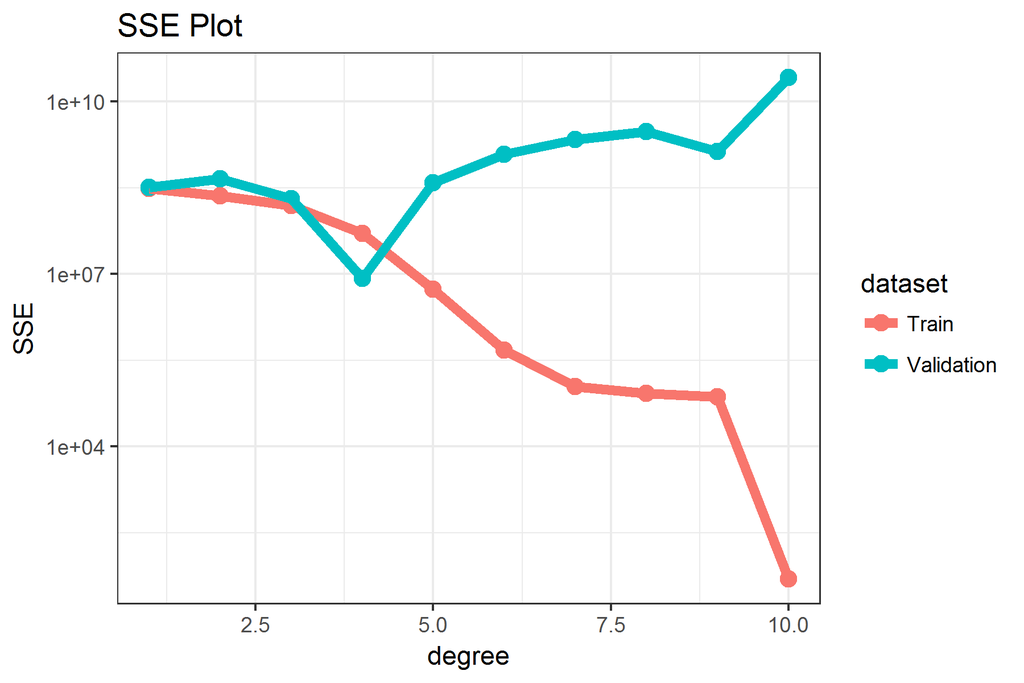

## NTREE

От вас потребуется построить график зависимости ошибок от параметра ntree. Я бы перебрал ntree в интервале seq(1, 1000, 5), но вы можете перебрать более удобные для вас значения: хочется лишь, чтобы начальное значение было достаточно маленьким, а конечное – достаточно большим.

Если вы все сделаете правильно, что вне зависимости от остальных параметров, которые определяют построение деревьев внутри случайного леса, **начиная с какого-то момента, количество деревьев не влияет на результат** ни в худшую, ни в лучшую сторону. **Зафиксируйте это количество деревьев, и используйте это число до конца выполнения домашней работы.**

## REPLACE and SAMPSIZE

В этой части задания, я хочу, чтобы вы зафиксировали значения параметров **ntree** (из прошлого пункта), **mtry=10** (хотим, чтобы когда строили деревья, всем правилам были доступны все features), и **nodesize=1** (хотим, чтобы в листовых вершинах оставалось по одному значению).

Я хочу, чтобы вы для этих “легко переобучаемых деревьях”, оценили эффект переобучения в зависимости от параметров replace и sampsize.

1. график зависимости ошибки от **sampsize** (1:40) при **replace**=F
2. грфаик зависимости ошибки от **sampsize** (1:40) при **replace**=T

Посмотрев на эти графики, напишите словами, какая из этих моделей переобучается сильнее. **Зафиксируйте значения replace и sampsize, для наименее переобученной модели, и используйте эти значения до конца выполнения домашней работы.**

## NODESIZE

В этой части задания, я хочу, чтобы вы зафиксировали значения параметров **ntree** (из первого пункта), **mtry=10** (хотим, чтобы когда строили деревья, всем правилам были доступны все features), **replace** и **sampsize** (взять из предыдущих пунктов).

Постройте график зависимости ошибки от **nodesize** (1:40).

1. Есть ли на этом графике переобучение?
2. **Определите оптимальное значение nodesizе, зафиксируйте его и используйте это значение до конца выполнения домашней работы.**

Обратите внимание, что здесь стоить смотреть на график “справа налево”, так как при большом nodesize мы считаем decision tree недообученными, а при малом – переобученными.

## MTRY

В этой части задания, я хочу, чтобы вы зафиксировали значения параметров **ntree**, **replace** и **sampsize**, **nodesize** из предыдущих пунктов

Постройте график зависимости ошибки от **mtry** (1:10).

1. Есть ли на этом графике переобучение?
2. **Определите оптимальное значение mtry, зафиксируйте его и используйте это значение до конца выполнения домашней работы.**

# CROSS VALIDATION

Теперь, когда вы выбрали значения всех параметров для нашего случайного леса, я хочу, чтобы вы сделали *кросс-валидацию*. Кросс-валидация – это процесс, когда мы разбиваем датасет на части, и по очереди используем каждую часть в качестве тестирующей выборки, а остальное – в качестве тренирующей. Затем берем среднее значение ошибки по всем частям, и выдаем из за результат.

Ниже я покажу, как сделать кросс-валидацию на randomForest со значениями по умолчанию: разобьем всех наших доноров на 5 частей по 10 человек в каждой части, по очереди будем использовать эти части, как тестирующие выборки, а оставшуюся часть датасета как обучающую. Посчитаем ошибку для каждого разбиения и затем среднюю ошибку.

Вам же нужно подставить в randomForest свои параметры, и посмотреть как хорошо работает ваш random forest по сравнению со случайным лесом по умолчанию.

```r
# our data, matrix 50 donors by 10 methylation sites
dim(data)
```

```
## [1] 50 10
```

```r
# age of all donors
head(response)
```

```
## [1] 20 21 22 23 24 25
```

```r
set.seed(1)

# splitting our dataset into 5 equal parts
cross.validation <- matrix(sample(1:50, 50), nrow=5, ncol=10)
cross.validation
```

```
##      [,1] [,2] [,3] [,4] [,5] [,6] [,7] [,8] [,9] [,10]
## [1,]   14   41    9   18   47   46   31   11   16    22
## [2,]   19   42    7   25   39    1   12   36    6    24
## [3,]   28   29   44   33   49   40   23    2   26    32
## [4,]   43   27   15   13    4   20   38   35   17    45
## [5,]   10    3   48   34   30    8   50    5   21    37
```

```r
cross.results <- apply(cross.validation, 1, function(test.sample){
  # using each part as testing dataset
  # using rest of the dataset as training dataset
  train.sample <- (1:50)[-test.sample]
  train.data <- data[train.sample, ]
  train.response <- response[train.sample]
  test.data <- data[test.sample, ]
  test.response <- response[test.sample]

  # calculating RMSE for every part and default random forest
  return(wrapper(train.data, train.response, test.data, test.response, 100))
})

print(cross.results)
```

```
##          [,1]      [,2]     [,3]      [,4]     [,5]
## [1,]  4.60202  5.096748 5.275979  4.375839 5.178482
## [2,] 12.02815 10.302521 8.361445 12.470508 8.924062
```

```r
print(rowMeans(cross.results))
```

```
## [1]  4.905814 10.417338
```